[figure not shown]

Painlessly Merge Data into Actuarial Loss Development

Triangles with R

Sam Castillo

December 31, 2017

Contents

Step 1: Organize the Excel Files 1

Step 2: Load the Data into R 2

Step 3: Create Development Triangles 3

Objective:

Create a method which easily combines loss runs, or listings of insurance claims, into triangles. Using only

Excel, the common method is to create links between the excel ﬁles which must be updated manually at each

new evaluation. This is prone to human error and is time consuming. Using a script to merge the ﬁles ﬁrst

and then create a triangle saves time and is more consistent.

Follow along with the data and Rmd ﬁle from github:https://github.com/sdcastillo/Loss-Development-Triangles

For a deﬁnition of a loss development triangle and why they are important, see Wikipedia: https://en.

wikipedia.org/wiki/Chain-ladder_method

Methods:

I use the packages

plyr

,

dplyr

,

tidyr

, and

lubridate

to manipulate the data once it is loaded into R. The

package

readxl

reads the excel ﬁles from the windows ﬁle directory. It is worth noting that all ﬁve of these

packages are included in Hadley Wickham’s

tidyverse

package. The package

ChainLadder

has a variety of

tools for actuarial reserve analysis.

library(dplyr)

library(readxl)

library(plyr)

library(tidyr)

library(ChainLadder)

library(lubridate)

Step 1: Organize the Excel Files

Copy all of the excel ﬁles into the same windows folder, inside the working directory of the R project. It is

important to have only the ﬁles that are going to be loaded into R in this folder.

On my computer, my ﬁle structure is as follows:

C:/Users/Sam/Desktop/[R project working directory]/[folder with excel claims listing ﬁles to aggregate]/[ﬁle

1, ﬁle 2, ﬁle 3, etc]

Using the command

list.files()

, R automatically looks in the working directory and returns a vector of

all the the ﬁle names which it sees. For example, R sees the data ﬁles in the current working directory:

1

[figure not shown]

#setwd("projects/Excel Aggregate Loop/excel files")

wd_path = "C:/Users/Sam/Desktop/projects/Excel Aggregate Loop/excel files"

list.files(wd_path)

## [1] "claims listing 2011.xlsx" "claims listing 2012.xlsx"

## [3] "claims listing 2013.xlsx" "claims listing 2014.xlsx"

## [5] "claims listing 2015.xlsx" "claims listing 2016.xlsx"

R can then loop through each of these ﬁles and perform any action. If there were 100 ﬁles, or 1000 ﬁles in

this directory, this would still work.

The loss ﬁles have dummy data for a claims listing. Each row is an individual claim which would have

a member name, memberID, loss date, report date, paid loss amount, incurred loss amount, case reserve

amount, etc. To make this as realistic as possible, the have artibtrary columns in addition to the ones which

we need, file year, loss date, and paid.

file_names = list.files(wd_path)

file_paths = paste(wd_path, "/", file_names, sep = "")

head(read_excel(file_paths[4]) %>% select(-3,-4,-5))

## # A tibble: 4 x 6

## name `license number` age `file year` `loss date` paid

## <chr> <dbl> <dbl> <dbl> <dttm> <dbl>

## 1 jeff 3 23 2014 2011-01-01 400

## 2 sue 3 43 2014 2012-01-01 400

## 3 mark 2 55 2014 2013-01-01 200

## 4 sarah 1 100 2014 2014-01-01 500

In order to evaluate the age of the losses, we need to take into account when each loss was evaluated. This is

accomplished by going into Excel and adding in a column for “ﬁle year”, which speciﬁes the year of evaluation

of the ﬁle. For instance, for the “claim listing 2013” ﬁle, all of the claims have a “2013” in the “ﬁle year”

column.

Step 2: Load the Data into R

Initialize a data frame which will store the aggregated loss run data from each of the excel ﬁles.

The names

of this data frame need to be the names of excel ﬁle columns which need to be aggregated.

For instance, these could be “reported”, “Paid Loss”, “Case Reserves”, or “Incurred Loss”. If the excel ﬁles

have diﬀerent names for the same quantities (ie, “Paid Loss” vs. “paid loss”), then they should be renamed

within excel ﬁrst.

merged_data = as_data_frame(matrix(nrow = 0, ncol = 3))

names(merged_data) = c("file year", "loss date", "paid")

Someone once said “if you need to use a ‘for’ loop in R, then you are doing something wrong”. Vectorized

functions are faster and easier to implement. The function

below takes in the ﬁle name of the

excel ﬁle and returns a data frame with only the columns which are selected.

excel_file_extractor = function(cur_file_name){

read_excel(cur_file_name[1], sheet = "Sheet1", col_names = T) %>%

select(`file year`, `file year`, `loss date`, paid) %>%

rbind(merged_data)

}

Apply the function to all of the ﬁles in the folder that you created. Obviously, if you had 100 excel ﬁles this

would still work just as eﬀectively.

2

[figure not shown]

From the

plyr

package,

ldply

takes in a list and returns a data frame. The way to remember this is by the

ordering of the letters (“list”-“data frame”-“ply”). For example, ﬀ we wanted to read in a data frame and

return a data frame, it would be ddply.

loss_run_data = ldply(file_paths, excel_file_extractor)

names(loss_run_data) = c("file_year", "loss_date", "paid losses")

The data now has only the columns what we selected, despite the fact that the loss run ﬁles had diﬀerent

columns in each of the ﬁles.

glimpse(loss_run_data)

## Observations: 21

## Variables: 3

## $ file_year <dbl> 2011, 2012, 2012, 2013, 2013, 2013, 2014, 2014, 20...

## $ loss_date <dttm> 2011-01-01, 2011-01-01, 2012-01-01, 2011-01-01, 2...

## $ paid losses <dbl> 100, 200, 300, 300, 350, 100, 400, 400, 200, 500, ...

head(loss_run_data)

## file_year loss_date paid losses

## 1 2011 2011-01-01 100

## 2 2012 2011-01-01 200

## 3 2012 2012-01-01 300

## 4 2013 2011-01-01 300

## 5 2013 2012-01-01 350

## 6 2013 2013-01-01 100

Step 3: Create Development Triangles

Finally, once we have the loss run combined, we just need to create a triangle. This is made easy by the

as.triangle function from the ChainLadder package.

The only manual labor required in excel was to go into each ﬁle and create the

file year

column, which

was just the year of evaluation of each loss run ﬁle.

loss_run_data = loss_run_data %>%

mutate(accident_year = as.numeric(year(ymd(loss_date))),

maturity_in_months = (file_year - accident_year)*12)

merged_triangle = as.triangle(loss_run_data,

dev = "maturity_in_months",

origin = "accident_year",

value = "paid losses")

merged_triangle

## maturity_in_months

## accident_year 0 12 24 36 48 60

## 2011 100 200 300 400 450 450

## 2012 300 350 400 400 400 NA

## 2013 100 200 250 250 NA NA

## 2014 500 550 600 NA NA NA

## 2015 100 300 NA NA NA NA

## 2016 400 NA NA NA NA NA

3

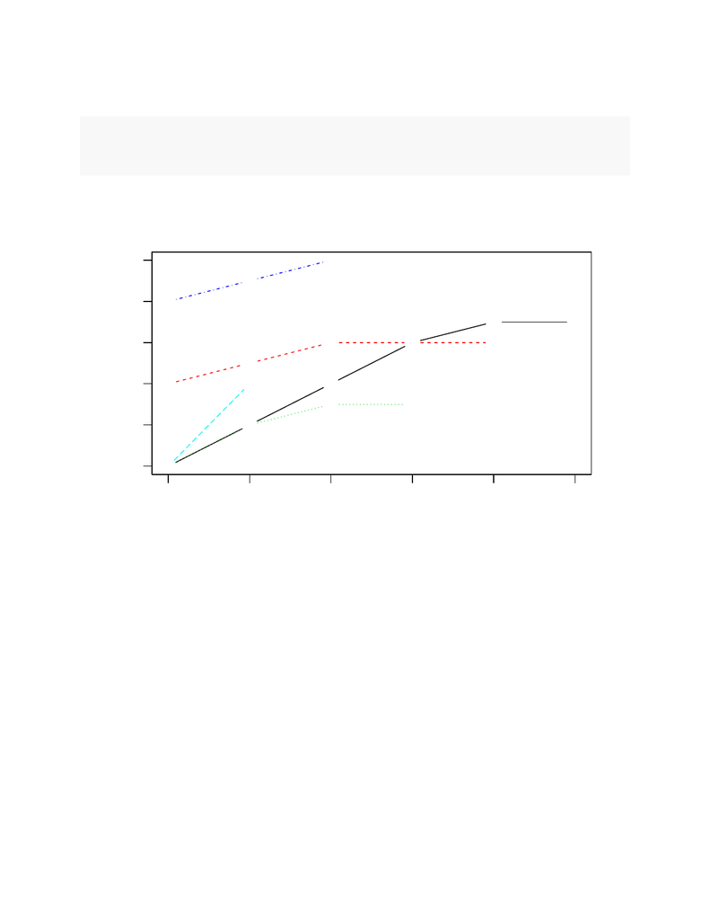

Within the package

ChainLadder

is a plot function, which shows the development of losses by accident year.

Because these are arbitrary amounts, the plot is not realistic.

plot(merged_triangle,

main = "Paid Losses vs Maturity by Accident Year",

xlab = "Maturity in Months",

ylab = "Paid Losses")

1

1

1

1

1 1

1 2 3 4 5 6

100 200 300 400 500 600

Paid Losses vs Maturity by Accident Year

Maturity in Months

Paid Losses

2

2

2 2 2

3

3

3 3

4

4

4

5

5

6

Conclusion:

When it comes to aggregating excel ﬁles, R can be faster and more consistent than linking together each of

the excel ﬁles, and once this script is set in place, making modiﬁcations to the data can be done easily by

editing the exel_file_extractor function.

4